# Struktur Data

Struktur data merupakan cara programmer untuk merepresentasikan suatu data, dan memudahkan programmer untuk menyelesaikan permasalahan dengan menggunakan struktur data tersebut. Struktur data Linear Structure merupakan struktur data sederhana dimana ketika data ditambahkan maka data tersebut berada pada posisi relatif terhadap data yang lain dari struktur data tersebut. Linear structure ini memiliki dua buah ujung. Dua buah ujung ini memiliki beberapa istilah seperti left-right, front-rear, ataupun top-bottom. Terdapat beberapa struktur data yang termasuk pada linear structure ini, yaitu :

- Stacks
- Queues
- Lists Ketiga jenis struktur data tersebut berbeda dalam penambahan atau penghapusan suatu data. Misalkan, suatu struktur data hanya diperbolehkan menghapus data pada salah satu ujung, sedangkan pada struktur data lain, penghapusan data dapat dilakukan pada kedua ujung.

# Definisi Stacks

Stacks adalah satu struktur data dimana penambahan dan penghapusan data, hanya dapat dilakukan pada satu ujung yang sama, atau yang biasa dikenal dengan istilah top. Semakin data jauh berada dari posisi top, maka data tersebut diindikasikan berada di stack lebih lama dibandingkan dengan data yang berada dekat pada data di posisi top. Jika terdapat data baru yang ditambahkan di stack, maka data ini pulalah yang akan dihapus ketika terdapat proses penghapusan data. Konsep ini dikenal dengan nama LIFO-Last In First Out.

Konsep stack ini dapat ditemui pada permasalahan sehari-hari, misalkan tumpukan buku pada Gambar 1 berikut.

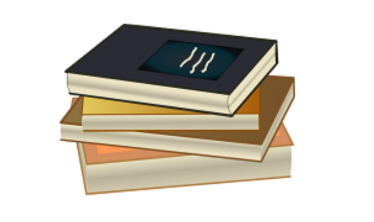

Gambar 1. Tumpukan buku Jika kita ingin mengambil buku pada tumpukan buku tersebut, maka buku yang dapat kita ambil adalah buku yang berada di posisi teratas. Jika ingin mengambil buku yang berada di posisi paling bawah, maka kita harus mengambil buku-buku yang berada di posisi atasnya terlebih dahulu. Begitu juga ketika terdapat penambahan buku baru, maka buku baru ini akan berada di posisi paling atas.

# Operasi pada Stacks

Terdapat operasi dasar pada Stacks,

- stack (), inisialisasi stack yang kosong
- push(data), penambahan data baru pada posisi top dari stack
- pop(), penghapusan data yang terdapat di posisi top dari stack. R eturn value dari fungsi ini adalah data yang dihapus dari stack tersebut
- peek(), informasi data yang terletak pada posisi top
- isEmpty(), untuk memeriksa apakah stack dalam keadaan kosong
- size(), informasi jumlah data yang terdapat pada stack

Ilustrasi proses penambahan data atau yang dikenal dengan istilah push dapat dilihat pada Gambar 2 berikut.

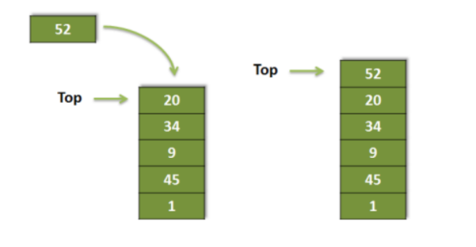

# Gambar 2. Operasi push pada Stacks

Sedangkan proses penghapusan data atau yang dikenal dengan istilah pop dapat dilihat pada Gambar 3 berikut.

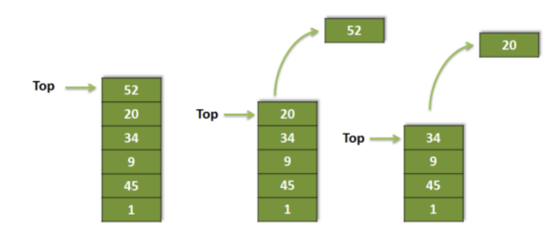

```python
stack = []

stack.append('S')
stack.append('A')
stack.append('K')
stack.append('I')
print("Stack: ", stack)
print("Size: ",len(stack))

hapus = stack.pop()
print("Pop: ", hapus)
print("Size: ",len(stack))
```

```
Stack:  ['S', 'A', 'K', 'I']
Size:  4
Pop:  I
Size:  3
```

```python
class Stack:
  def __init__(self):
    self.stack = []

  def push(self, element):
    self.stack.append(element)

  def pop(self):
    if self.isEmpty():
      return "Stack is empty"
    return self.stack.pop()

  def peek(self):
    if self.isEmpty():
      return "Stack is empty"
    return self.stack[-1]

  def isEmpty(self):
    return len(self.stack) == 0

  def size(self):
    return len(self.stack)

# Create a stack
myStack = Stack()

myStack.push('A')
myStack.push('B')
myStack.push('C')

print("Stack: ", myStack.stack)
print("Pop: ", myStack.pop())
print("Stack after Pop: ", myStack.stack)
print("Peek: ", myStack.peek())
print("isEmpty: ", myStack.isEmpty())
print("Size: ", myStack.size())
```

```
Stack:  ['A', 'B', 'C']
Pop:  C
Stack after Pop:  ['A', 'B']
Peek:  B
isEmpty:  False
Size:  2
```

```python
#Stack dengan menggunakan def/Function
def push(s,data):
    s.append(data)
def pop(s):
    data=s.pop()
    return(data)
def peek(s):
    return(s[-1])
def isEmpty(s):
    return (s==[])
def size(s):
    return len(s)

s=[]

push(s,100)
pop(s)
push(s,200)
pop(s)
push(s,'s')
push(s,'a')
push(s,'k')
push(s,'i')
peek(s)
```

```
'i'
```

```python
print(size(s))
```

```
4
```

```python
kata = 'KATAK'
A = []
B = []

def pushh(s, objek):
    for i in range(len(objek)):
        s.append(objek[i])
    print(s)

def pushh2(s, objek):
    for j in range(len(objek),0,-1):
        s.append(objek[j-1])
    print(s)

def cekKata(a,b):
    return a==b

pushh(A, kata)
pushh2(B, kata)
print(cekKata(A,B))
```

```
['K', 'A', 'T', 'A', 'K']
['K', 'A', 'T', 'A', 'K']
True
```

# Tugas

```python
stack = []
while True:
    teks = input('Masukkan Kata = ')

    if teks.upper() == 'UNDO':
        if stack:
            stack.pop()
            print('Berhasil melakukan UNDO')
        else:
            print('tidak kata yang di UNDO')
            break
    else:
        stack.append(teks)

    if stack:
        print('output = ',stack [-1])
    else:
        print('output kosong')
```

```
output =  a
```

```
output =  b
```

```
output =  c
```

```
Berhasil melakukan UNDO
output =  b
```

```
Berhasil melakukan UNDO
output =  a
```

```
Berhasil melakukan UNDO
output kosong
```

```
output =  undi
```

```
Berhasil melakukan UNDO
output kosong
```

```
tidak kata yang di UNDO
```

```python
stack = []
panjang_data= 0

stack.append(10)
stack.append(50)
stack.append(30)
stack.append(90)
stack.append(30)

for i in stack:
    panjang_data+=1
print('jumlah elemen dalam stack = ',panjang_data)
```

```
jumlah elemen dalam stack =  5
```

```python
stack = []

stack.append(10)
stack.append(20)
stack.append(30)
stack.append(40)
stack.append(50)

print(stack)

stack.pop()
stack.pop()
stack.pop()
stack.append(40)
stack.append(50)

print(stack)
```

```
[10, 20, 30, 40, 50]
[10, 20, 40, 50]
```

```python
kata = input('masukkan kata = ')
stack = []
revers = []

def push(s, objek):
    for i in range(len(objek)):
        s.append(objek[i])
    print(s)

def push2(s, objek):
    for j in range(len(objek),0,-1):
        s.append(objek[j-1])
    print(s)

push(stack,kata)
push2(revers,kata)
```

```
['k', 'a', 's', 'u', 'r']
['r', 'u', 's', 'a', 'k']
```

# Ekspressi Aritmatik Infix, Prefix, Postfix

Berikut contoh ekspressi aritmatik infix dan konversinya ke prefix dan postfix.

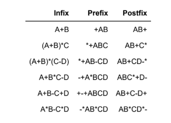

# INFIX -> POSTFIX

```python
def prec(c):
    if c == '^':
        return 3
    elif c == '/' or c == '*':
        return 2
    elif c == '+' or c == '-':
        return 1
    else:
        return -1

def isRightAssociative(c):
    return c == '^'

def infixToPostfix(s):
    st = []
    res = []

    for c in s:
        # If operand, add to result
        if ('a' <= c <= 'z') or ('A' <= c <= 'Z') or ('0' <= c <= '9'):
            res.append(c)

        # If '(', push to stack
        elif c == '(':
            st.append('(')

        # If ')', pop until '('
        elif c == ')':
            while st and st[-1] != '(':
                res.append(st.pop())
            st.pop()

        # If operator
        else:
            while st and st[-1] != '(' and \
                (prec(st[-1]) > prec(c) or (prec(st[-1]) == prec(c) \
                                    and not isRightAssociative(c))):
                res.append(st.pop())
            st.append(c)

    # Pop remaining operators
    while st:
        res.append(st.pop())

    return ''.join(res)

if __name__ == '__main__':
    exp = "a*(b+c)/d"
    print(infixToPostfix(exp))
```

```
abc+*d/
```

# INFIX -> PREFIX

```python
# function to return precedence of operators
def precedence(c):
    if c == '^':
        return 3
    elif c in ('*', '/'):
        return 2
    elif c in ('+', '-'):
        return 1
    else:
        return -1

# function to check if operator is right-associative
def isRightAssociative(c):
    return c == '^'

# function to check if a character is an operator
def isOperator(c):
    return c in "+-*/^"

# function to convert infix expression to prefix
def infixToPrefix(s):
    st = []
    result = []

    # scan from right to left
    for c in reversed(s):
        if c.isalnum():
            result.append(c)
        elif c == ')':
            st.append(c)
        elif c == '(':
            while st and st[-1] != ')':
                result.append(st.pop())
            if st:
                st.pop()  # remove ')'
        elif isOperator(c):
            while (st and isOperator(st[-1]) and
                  (precedence(st[-1]) > precedence(c) or
                  (precedence(st[-1]) == precedence(c) and isRightAssociative(c)))):
                result.append(st.pop())
            st.append(c)

    # pop remaining operators
    while st:
        result.append(st.pop())

    # reverse at the end to get correct prefix
    return ''.join(reversed(result))

if __name__ == "__main__":
    s = input('Masukkan Infix = ')
    print(infixToPrefix(s))
```

```
+ab
```